# code

```python
from google.colab import drive
drive.mount('/content/drive')
```

```python
import pandas as pd
```

```python
cal = pd.read_csv('/content/drive/MyDrive/DS/Proj_1/calendar.csv')
lit = pd.read_csv('/content/drive/MyDrive/DS/Proj_1/listings.csv')
rev = pd.read_csv('/content/drive/MyDrive/DS/Proj_1/reviews.csv')
```

Calendar: remove False Listing: Keep available rooms by merging with Calendar Review: Do nothing

# Overview

- Dataset usage
- 3 big questions
- Pretend: Let's say a group of visitors travels in 1st,Dec,2016 and plans to stay in Boston,US. What room is available to them during that days?
- What are the prices between streets in Boston?
- Presumably,Could the room type and other facilities contribute to the differences in price?

# Prepare data

```python
# Get available listing
cal = cal[cal.available == 't']
```

```python
#Merge
# Street should be splitted and keep only street name
lit_ = lit[['id','longitude','latitude','street','city', 'state','country_code','property_type', 'room_type', 'bed_type','bedrooms','beds',
'minimum_nights','number_of_reviews','review_scores_rating', 'review_scores_accuracy','review_scores_cleanliness',
'review_scores_checkin', 'review_scores_communication', 'review_scores_location','review_scores_value']]
df = pd.merge(cal[['listing_id','date','price']],lit_.rename(columns = {'id':'listing_id'}),on = 'listing_id',how = 'inner')
```

```python
# Precessing street column:
df.street = [i.split(',')[0] for i in df.street]
```

```python
#Drop all nan values
df = df.dropna()
```

```python
# Convert to datetime type
df.date = pd.to_datetime(df.date)

# Convert string to currency for price
df['price'] = df['price'].apply(lambda x: float(x[1:].replace(',','')))
```

```python
df.to_csv('/content/drive/MyDrive/DS/Proj_1/cleaned_data.csv', index = False)
```

# Analyze and Visualize

## Question 1: Available places

Pretend: Let's say a group of visitors travels in 1st,Dec,2016 and plans to stay in Boston,US for 3 days. What room is available to them during that days?

```python
import datetime
import pandas as pd
df_ = pd.read_csv('/content/drive/MyDrive/DS/Proj_1/cleaned_data.csv')
df_.date = pd.to_datetime(df_.date)
# Find places have date over than 2016, Dec, 1
df_ = df_[(df_.date >= datetime.datetime(2016, 12, 1)) & (df_.date <= datetime.datetime(2016, 12, 4)) & (df_.city == 'Boston')]
```

```python
df_
```

|  | listing_id | date | price | longitude | latitude | street | city | state | country_code | property_type | ... | beds | minimum_nights | number_of_reviews | review_scores_rating | review_scores_accuracy | review_scores_cleanliness | review_scores_checkin | review_scores_communication | review_scores_location | review_scores_value |
| --- | --- | --- | --- | --- | --- | --- | --- | --- | --- | --- | --- | --- | --- | --- | --- | --- | --- | --- | --- | --- | --- |
| 260 | 3075044 | 2016-12-04 | 65.0 | -71.134374 | 42.286241 | Pinehurst Street | Boston | MA | US | Apartment | ... | 1.0 | 2 | 36 | 94.0 | 10.0 | 9.0 | 10.0 | 10.0 | 9.0 | 9.0 |
| 261 | 3075044 | 2016-12-03 | 75.0 | -71.134374 | 42.286241 | Pinehurst Street | Boston | MA | US | Apartment | ... | 1.0 | 2 | 36 | 94.0 | 10.0 | 9.0 | 10.0 | 10.0 | 9.0 | 9.0 |
| 262 | 3075044 | 2016-12-02 | 75.0 | -71.134374 | 42.286241 | Pinehurst Street | Boston | MA | US | Apartment | ... | 1.0 | 2 | 36 | 94.0 | 10.0 | 9.0 | 10.0 | 10.0 | 9.0 | 9.0 |
| 263 | 3075044 | 2016-12-01 | 65.0 | -71.134374 | 42.286241 | Pinehurst Street | Boston | MA | US | Apartment | ... | 1.0 | 2 | 36 | 94.0 | 10.0 | 9.0 | 10.0 | 10.0 | 9.0 | 9.0 |
| 741 | 1436513 | 2016-12-04 | 75.0 | -71.121021 | 42.281106 | Boston | Boston | MA | US | House | ... | 2.0 | 1 | 1 | 100.0 | 10.0 | 10.0 | 10.0 | 10.0 | 10.0 | 10.0 |
| ... | ... | ... | ... | ... | ... | ... | ... | ... | ... | ... | ... | ... | ... | ... | ... | ... | ... | ... | ... | ... | ... |
| 507603 | 7462268 | 2016-12-01 | 75.0 | -71.129016 | 42.358198 | Hooker St | Boston | MA | US | House | ... | 1.0 | 1 | 32 | 97.0 | 10.0 | 10.0 | 10.0 | 10.0 | 9.0 | 10.0 |
| 509162 | 12915510 | 2016-12-04 | 229.0 | -71.048459 | 42.376376 | 13th Street | Boston | MA | US | Boat | ... | 5.0 | 2 | 4 | 100.0 | 10.0 | 10.0 | 10.0 | 10.0 | 10.0 | 10.0 |
| 509163 | 12915510 | 2016-12-03 | 429.0 | -71.048459 | 42.376376 | 13th Street | Boston | MA | US | Boat | ... | 5.0 | 2 | 4 | 100.0 | 10.0 | 10.0 | 10.0 | 10.0 | 10.0 | 10.0 |
| 509164 | 12915510 | 2016-12-02 | 429.0 | -71.048459 | 42.376376 | 13th Street | Boston | MA | US | Boat | ... | 5.0 | 2 | 4 | 100.0 | 10.0 | 10.0 | 10.0 | 10.0 | 10.0 | 10.0 |
| 509165 | 12915510 | 2016-12-01 | 229.0 | -71.048459 | 42.376376 | 13th Street | Boston | MA | US | Boat | ... | 5.0 | 2 | 4 | 100.0 | 10.0 | 10.0 | 10.0 | 10.0 | 10.0 | 10.0 |

6353 rows × 23 columns

```python
import folium

world_map=folium.Map()
map = folium.Map()

# pretend a traveller coming in to the US in 1, Dec, 2016. Query for available hotels
travel_date = datetime.datetime(2016,12,1)
available_places = df_[df_.date == travel_date].reset_index()

# PLot available hotels in World Map
for i in range(len(available_places)):
  ap = folium.map.FeatureGroup().add_child(folium.CircleMarker((available_places.latitude[i],available_places.longitude[i]),radius = 5,color='red',fill_color='Red'))
  world_map.add_child(ap)
world_map
```

Make this Notebook Trusted to load map: File -> Trust Notebook

[interactive chart not shown]

## Question 2: What are the prices between streets in Boston?

```python
available_places.head()
```

|  | index | listing_id | date | price | longitude | latitude | street | city | state | country_code | ... | beds | minimum_nights | number_of_reviews | review_scores_rating | review_scores_accuracy | review_scores_cleanliness | review_scores_checkin | review_scores_communication | review_scores_location | review_scores_value |
| --- | --- | --- | --- | --- | --- | --- | --- | --- | --- | --- | --- | --- | --- | --- | --- | --- | --- | --- | --- | --- | --- |
| 0 | 263 | 3075044 | 2016-12-01 | 65.0 | -71.134374 | 42.286241 | Pinehurst Street | Boston | MA | US | ... | 1.0 | 2 | 36 | 94.0 | 10.0 | 9.0 | 10.0 | 10.0 | 9.0 | 9.0 |
| 1 | 978 | 7651065 | 2016-12-01 | 79.0 | -71.136258 | 42.284512 | Durnell Avenue | Boston | MA | US | ... | 2.0 | 2 | 29 | 99.0 | 10.0 | 10.0 | 10.0 | 10.0 | 9.0 | 10.0 |
| 2 | 1113 | 12386020 | 2016-12-01 | 75.0 | -71.131893 | 42.291690 | Walter Street | Boston | MA | US | ... | 1.0 | 2 | 8 | 100.0 | 10.0 | 10.0 | 10.0 | 10.0 | 9.0 | 10.0 |
| 3 | 1446 | 5706985 | 2016-12-01 | 100.0 | -71.131190 | 42.281390 | Kittredge Street | Boston | MA | US | ... | 2.0 | 1 | 57 | 90.0 | 10.0 | 10.0 | 10.0 | 10.0 | 9.0 | 9.0 |
| 4 | 1788 | 2843445 | 2016-12-01 | 75.0 | -71.141022 | 42.281946 | Cornell Street | Boston | MA | US | ... | 1.0 | 1 | 67 | 96.0 | 10.0 | 10.0 | 10.0 | 10.0 | 10.0 | 10.0 |

5 rows × 24 columns

```python
prices = available_places.dropna()[['street','price']].groupby('street').mean().sort_values('price').reset_index()
num_places = available_places.dropna()[['street','price']].groupby('street').count().rename(columns = {'price':'num_places'}).sort_values('num_places').reset_index()
```

```python
street_group = pd.merge(prices,num_places,on = 'street')
crowded_streets = street_group[street_group.num_places > 6].street.values
```

```python
street_group.num_places.value_counts()
```

```
1     347
2     131
3      53
4      23
5      21
6      13
7      11
9       4
8       3
33      2
17      2
12      2
15      2
10      1
22      1
14      1
28      1
40      1
23      1
11      1
32      1
18      1
26      1
Name: num_places, dtype: int64
```

```python
street_group.sort_values('num_places').tail()
```

|  | street | price | num_places |
| --- | --- | --- | --- |
| 474 | Commonwealth Avenue | 214.750000 | 28 |
| 530 | Boylston Street | 266.875000 | 32 |
| 417 | Tremont Street | 182.666667 | 33 |
| 534 | Washington Street | 273.393939 | 33 |
| 475 | Beacon Street | 214.900000 | 40 |

Looking at the num of places in each street, we can see that some streets have lots of hotels. Let's find out Do those streets have hotels are nearly the same prices or there are still the differences in prices? ( num_places > 6)

Box plot

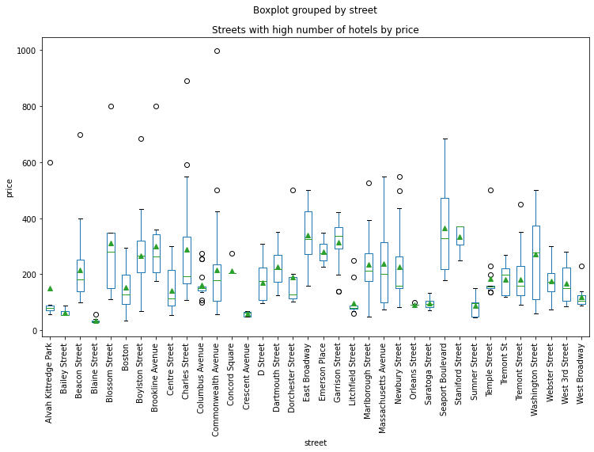

```python
import matplotlib.pyplot as plt

available_places.set_index('street').loc[crowded_streets,:].reset_index().boxplot('price','street',grid = False,rot=90,figsize = (12,7),showmeans=True)
plt.ylabel('price')
plt.title('Streets with high number of hotels by price')
```

Bed types

```python
available_places.columns
```

```
Index(['index', 'listing_id', 'date', 'price', 'longitude', 'latitude',
       'street', 'city', 'state', 'country_code', 'property_type', 'room_type',
       'bed_type', 'bedrooms', 'beds', 'minimum_nights', 'number_of_reviews',
       'review_scores_rating', 'review_scores_accuracy',
       'review_scores_cleanliness', 'review_scores_checkin',
       'review_scores_communication', 'review_scores_location',
       'review_scores_value'],
      dtype='object')
```

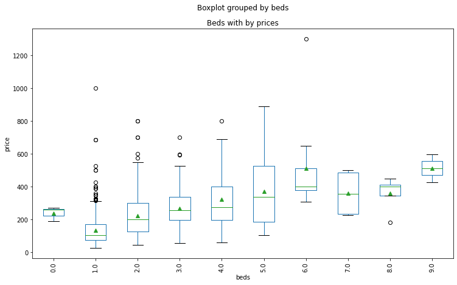

```python
# analysed_streets = ['Beacon Street','Blossom Street','Boylston Street','Brookline Avenue','Charles Street','Columbus Avenue','Commonwealth Avenue']
available_places.boxplot('price','beds',grid = False,rot=90,figsize = (12,7),showmeans=True)
plt.ylabel('price')
plt.title('Beds with by prices')
```

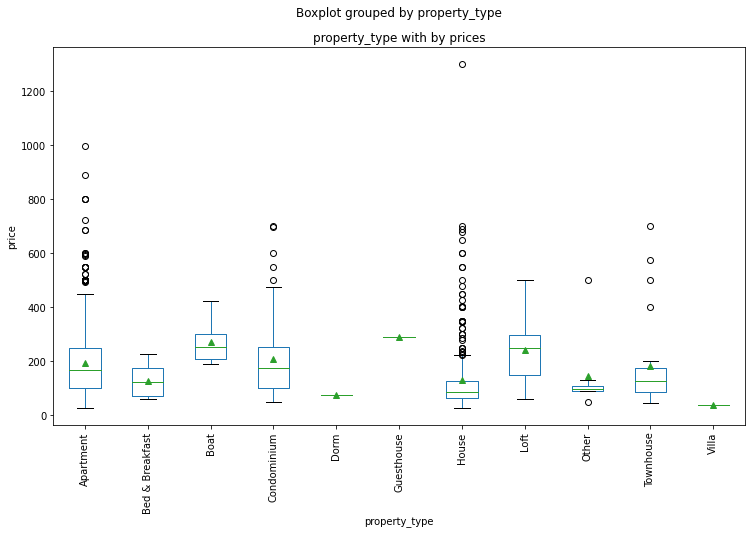

```python
available_places.boxplot('price','property_type',grid = False,rot=90,figsize = (12,7),showmeans=True)
plt.ylabel('price')
plt.title('property_type with by prices')
```

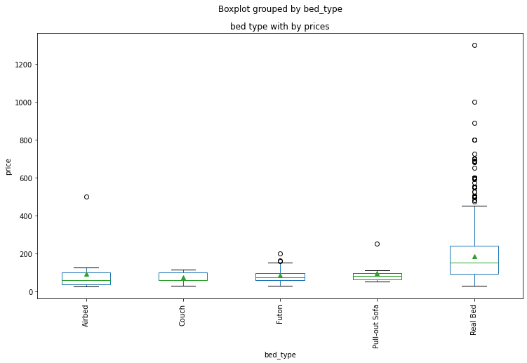

```python
available_places.boxplot('price','bed_type',grid = False,rot=90,figsize = (12,7),showmeans=True)
plt.ylabel('price')
plt.title('bed type with by prices')
```

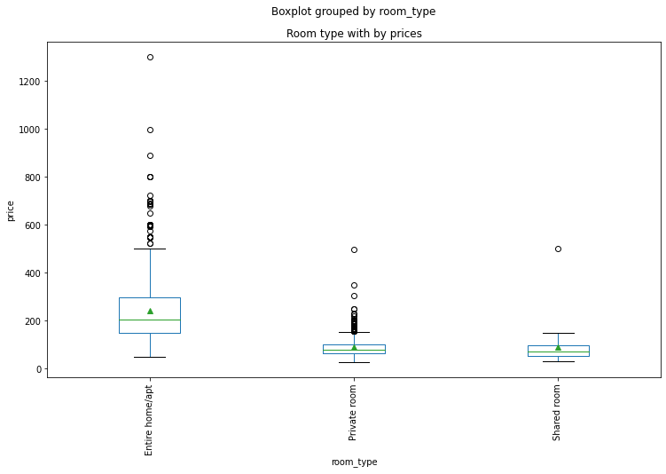

```python
available_places.boxplot('price','room_type',grid = False,rot=90,figsize = (12,7),showmeans=True)
plt.ylabel('price')
plt.title('Room type with by prices')
```

### Apartment vs House

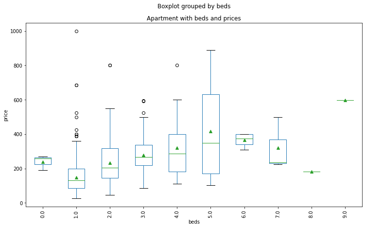

```python
available_places[available_places.property_type == 'Apartment'].boxplot('price','beds',grid = False,rot=90,figsize = (12,7),showmeans=True)
plt.ylabel('price')
plt.title('Apartment with beds and prices')
```

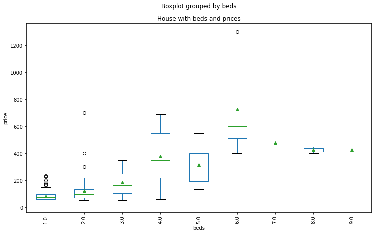

```python
available_places[available_places.property_type == 'House'].boxplot('price','beds',grid = False,rot=90,figsize = (12,7),showmeans=True)
plt.ylabel('price')
plt.title('House with beds and prices')
```

### Crowded Street

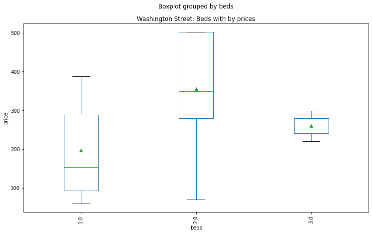

```python
# analysed_streets = ['Beacon Street','Blossom Street','Boylston Street','Brookline Avenue','Charles Street','Columbus Avenue','Commonwealth Avenue']
available_places[available_places.street == 'Washington Street'].boxplot('price','beds',grid = False,rot=90,figsize = (12,7),showmeans=True)
plt.ylabel('price')
plt.title('Washington Street: Beds with by prices')
```

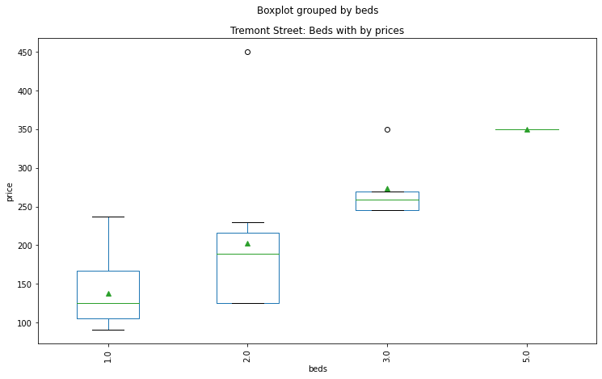

```python
# Tremont Street
available_places[available_places.street == 'Tremont Street'].boxplot('price','beds',grid = False,rot=90,figsize = (12,7),showmeans=True)
plt.ylabel('price')
plt.title('Tremont Street: Beds with by prices')
```

All in all,the prices between places to stay avalable for a specific day (2016, Dec, 1) are different in not only street ( some crowded street have quite high prices, but also by the facilities those places have. Such as the bumber of beds, or rome_type like Apartment/ House and other facilities visullized in the boxplots above. The first hand analysis and the result can be used to support to filter data for a recommendation system in tourism. For deep dive analysis, we can add some mocked_user-requirement to have better results.

```python
%%shell
jupyter nbconvert --to html code.ipynb
```

[output not shown]

[output cut: 107 more lines]

[output not shown]

[output not shown]